# PS 812

Section 10: Midterm Review, Regression Tables, and Marginal Effects

John Hicks

Dept. of Political Science, UW-Madison

2026-11-13

# Today

## Today

**1. Midterm review: weeks 5 to 9** (~25 min)

One slide per week, then your questions. No practice problems

**2. Regression tables** with `modelsummary`

How to make one and how to read one

**3. Coefficient plots**

And why they mislead when regressors are on different scales

**4. Marginal effects** with `marginaleffects`

When a coefficient isn’t the answer, and visualizing interactions

**5. Getting tables and figures out of R** (if time, otherwise next week)

# Midterm review

## Week 5: Estimands

- The **estimand** is the target quantity, stated **before** you pick a method: a unit-level quantity, plus the target population to average it over
- **Descriptive** estimands summarize the world as it is ($\mathbb{E}[Y]$, $\mathbb{E}[Y \mid X = x]$). **Causal** estimands compare **potential outcomes**:

$$\tau_i = Y_i(1) - Y_i(0) \qquad \text{ATE} = \mathbb{E}[Y_i(1) - Y_i(0)]$$

- **Fundamental problem of causal inference**: we see at most one of $Y_i(1)$, $Y_i(0)$ for each unit
- **Identification**: with infinite data, could we learn $\theta$? This means writing $\theta$ in terms of the **observable** distribution. **Estimation** is the separate, finite-sample question
- **Ignorability**, $\{Y_i(1), Y_i(0)\} \perp\!\!\!\perp D_i$, is what lets $\mathbb{E}[Y_i(1)] = \mathbb{E}[Y_i \mid D_i = 1]$. **Conditional** ignorability gives the same thing within levels of $X$

## Week 6: Estimators are random variables

- Draw a new sample and you get a new $\hat\theta_n$. Its distribution across samples is the **sampling distribution**
- Properties of that distribution:
  - **Bias**: $\mathbb{E}[\hat\theta_n] - \theta$
  - **Variance** $\text{Var}(\hat\theta_n)$, and the **standard error** $SE = \sqrt{\text{Var}(\hat\theta_n)}$, the SD of the sampling distribution, **not** of $Y$
  - **MSE** $= \mathbb{E}[(\hat\theta_n - \theta)^2] = \text{Bias}^2 + \text{Var}$
- For an i.i.d. sample mean: $\mathbb{E}[\bar Y_n] = \mu$ (linearity + identically distributed) and $\text{Var}(\bar Y_n) = \sigma^2 / n$ (independence, so no covariances)
- **Consistency**: $\hat\theta_n \xrightarrow{p} \theta$, meaning $\Pr(|\hat\theta_n - \theta| \ge \epsilon) \to 0$ for every $\epsilon > 0$
- **WLLN**: $\bar Y_n \xrightarrow{p} \mu$. Proof: Chebyshev gives $\Pr(|\bar Y_n - \mu| \ge \epsilon) \le \frac{\sigma^2}{n\epsilon^2} \to 0$

## Bias and consistency

**To find a bias**, compute $\mathbb{E}[\hat\theta_n]$ and subtract $\theta$. The tool depends on the estimator:

- **An average of $g(Y_i)$** (transform each draw, *then* average), like $\frac{1}{n}\sum_i Y_i^2$: **linearity** reduces it to one draw, $\mathbb{E}\big[\frac{1}{n}\sum_i g(Y_i)\big] = \mathbb{E}[g(Y_i)]$. Then **LOTUS**, $\mathbb{E}[g(Y)] = \sum_y g(y) \Pr(Y = y)$, using the PMF of **the variable you actually sampled**
- **The square of an average** (average first, *then* square), $\bar Y_n^2 = \big(\frac{1}{n}\sum_i Y_i\big)^2$: the square sits outside the sum, so linearity can’t reduce it to one draw. Instead rearrange the variance formula with $X = \bar Y_n$: $\mathbb{E}[\bar Y_n^2] = \text{Var}(\bar Y_n) + \mathbb{E}[\bar Y_n]^2 = \frac{\sigma^2}{n} + \mu^2$
  - It overshoots $\mu^2$ by $\frac{\sigma^2}{n}$, the sampling variance of $\bar Y_n$. This is the term that biases the plug-in variance
- **Any other nonlinear function of an average**, like $1/\bar Y_n$: no exact answer, but $\mathbb{E}[g(X)] \neq g(\mathbb{E}[X])$, so expect bias. **Jensen** gives the direction: if $g$ is convex, $\mathbb{E}[g(X)] \ge g(\mathbb{E}[X])$, strictly if $g$ is strictly convex and $X$ isn’t constant

**To show consistency**:

- Write the estimator as an average of i.i.d. things → **WLLN**
- Then any continuous function of it → **continuous mapping theorem**: $X_n \xrightarrow{p} x \Rightarrow g(X_n) \xrightarrow{p} g(x)$. Sums, products, ratios (nonzero denominator) too
- Or: if $\text{Bias} \to 0$ **and** $\text{Var} \to 0$, the MSE goes to 0, and the estimator is consistent

## Unbiased and consistent are different properties

- **Biased but consistent**: the plug-in variance, $\mathbb{E}[\hat\sigma^2_n] = \frac{n-1}{n}\sigma^2$, but $\hat\sigma^2_n \xrightarrow{p} \sigma^2$
  - Same pattern for any $g(\bar Y_n)$ with nonlinear $g$: the CMT gives consistency, but $\mathbb{E}[g(\bar Y_n)] \neq g(\mu)$
- **Unbiased but not consistent**: use only the first observation, $\hat\mu = Y_1$. $\mathbb{E}[Y_1] = \mu$, but its variance is $\sigma^2$ at every $n$
- Unbiasedness is about the **center** of the sampling distribution at a **fixed** $n$. Consistency is about where it **collapses** as $n \to \infty$

## Week 7: CLT and plug-in

- **Convergence in distribution**: the CDFs converge. **CLT**: for i.i.d. $Y_i$ with finite variance,

$$\sqrt{n}(\bar Y_n - \mu) \xrightarrow{d} \mathcal{N}(0, \sigma^2) \qquad \text{so} \qquad \bar Y_n \overset{a}{\sim} \mathcal{N}(\mu, \sigma^2/n)$$

- Why $\sqrt n$: it’s the only scaling where the variance neither vanishes nor explodes. So $\bar Y_n - \mu = O_p(1/\sqrt n)$
- **Slutsky**: $X_n \xrightarrow{d} X$ and $Y_n \xrightarrow{p} c$ give $X_n / Y_n \xrightarrow{d} X / c$. This is why plugging in $\hat\sigma$ for $\sigma$ is fine in large samples
- **Plug-in principle**: write $\theta = T(F)$, then estimate with $T(\hat F_n)$, swapping in the empirical CDF. Means, variances, covariances, quantiles, regression coefficients
- **Densities** break the plug-in (the ECDF is a step function), so we smooth. Bin width in a histogram and bandwidth in a KDE: **bias-variance tradeoff**

## Week 8: Confidence intervals

$$\hat\theta_n \pm z_{1 - \alpha/2} \times \widehat{SE} \qquad (z_{0.975} = 1.96)$$

- A 95% CI is a **procedure** that covers $\theta$ in 95% of repeated samples. A **realized** interval either contains $\theta$ or it doesn’t
- Not “a 95% chance $\theta$ is in **this** interval”: $\theta$ is fixed, the interval is random
- Coverage relies on the CLT (asymptotic normality) and on a consistent $\widehat{SE}$
- **Small $n$**: use $t_{n-1}$ critical values. Exact when $Y$ is normal, wider than $\pm 1.96$, and the gap closes as $n$ grows
- **One-sided** intervals put all of $\alpha$ in one tail: $\hat\theta_n - z_{1-\alpha} \widehat{SE}$, with $z_{0.95} = 1.645$

## Week 8: Hypothesis tests

- $H_0: \theta = \theta_0$ vs. $H_1$. Test statistic $T = (\hat\theta_n - \theta_0) / \widehat{SE} \overset{a}{\sim} \mathcal{N}(0, 1)$ **under $H_0$**
- **Size** $\alpha = \Pr(\text{reject} \mid H_0)$, the Type I error rate. **Power** $= \Pr(\text{reject} \mid H_1) = 1 - \Pr(\text{Type II})$
- **p-value**: the probability, **if $H_0$ were true**, of a test statistic at least as extreme as the one observed. It is **not** $\Pr(H_0 \text{ true})$
- **Duality**: reject $H_0: \theta = \theta_0$ at level $\alpha$ $\iff$ $\theta_0$ is outside the $1 - \alpha$ CI
- **Multiple testing**: with $m$ true nulls at $\alpha$ each, the chance of at least one false rejection (FWER) grows fast
  - **Bonferroni**: reject if $p_j \le \alpha / m$
  - **Holm**: sort $p_{(1)} \le \dots \le p_{(m)}$. Reject while $p_{(k)} \le \alpha / (m - k + 1)$, and stop at the first failure. Same FWER control, more power

## Week 9: Regression

- The estimand is now the **CEF**, $\mu(x)$. Averaging at every $x$ fails with many covariates (**curse of dimensionality**), so we **borrow strength**: local averaging (kernels, bandwidth = bias-variance again) or a global model
- **BLP**: $\boldsymbol\beta = \arg\min_{\mathbf b} \mathbb{E}[(Y_i - \mathbf X_i'\mathbf b)^2] = \mathbb{E}[\mathbf X_i \mathbf X_i']^{-1}\mathbb{E}[\mathbf X_i Y_i]$. **OLS** is its plug-in: $\hat{\boldsymbol\beta} = (\mathbf X'\mathbf X)^{-1}\mathbf X'\mathbf Y$
- OLS exists iff $\mathbf X$ has **full column rank**: no regressor is a linear combination of the others (e.g. the dummy-variable trap)
- **Interpretation**: $\hat\beta_1$ is the difference in predicted $Y$ for a one-unit difference in $X_1$, **holding the other regressors fixed**
- **FWL**: $\hat\beta_1$ = slope from regressing $Y$-residuals on $X_1$-residuals, after partialling out the rest. It only uses variation in $X_1$ the others can’t **linearly** predict
- **Interactions**: in $\beta_0 + \beta_1 X_1 + \beta_2 X_2 + \beta_3 X_1 X_2$, the slope on $X_1$ is $\beta_1 + \beta_3 x_2$. $\beta_1$ alone is the slope **at $x_2 = 0$**

## Questions?

# Regression tables

## Data

Same ANES data as last week: Trump thermometer, hostile sexism, and racial resentment (both scaled 0 to 1), plus covariates

```r
anes <- read_csv("data/anes24_sexism.csv") |>
  mutate(woman = as.integer(gender == "Woman")) |>
  drop_na(ft_trump, hostile_sexism, racial_resentment, pid7, educ)

nrow(anes)
```

```
[1] 4533
```

- One sample for every model, so the columns of the table are comparable
- Otherwise, adding a control with missing values silently changes the sample too

## Four models

```r
library(fixest)

m1 <- feols(ft_trump ~ hostile_sexism,
            data = anes, vcov = "hetero")
m2 <- feols(ft_trump ~ hostile_sexism + racial_resentment,
            data = anes, vcov = "hetero")
m3 <- feols(ft_trump ~ hostile_sexism + racial_resentment | pid7,
            data = anes, vcov = "hetero")
m4 <- feols(ft_trump ~ hostile_sexism + racial_resentment | pid7 + educ,
            data = anes, vcov = "hetero")
```

- `feols()` is `lm()` with two conveniences:
  - `| pid7` adds a dummy for every value of `pid7` (**fixed effects**) without printing 7 coefficients
  - `vcov = "hetero"` gives **robust** standard errors, the ones from this week’s lecture
- `summary(m2)` is fine for you. It isn’t fine for a paper

## The default table

```r
library(modelsummary)

models <- list(m1, m2, m3, m4)
modelsummary(models)
```

## The default table

|  | (1) | (2) | (3) | (4) |
| --- | --- | --- | --- | --- |
| (Intercept) | 6.241 | -9.262 |  |  |
|  | (0.803) | (0.673) |  |  |
| hostile_sexism | 93.900 | 50.088 | 22.233 | 19.127 |
|  | (2.158) | (2.585) | (1.927) | (1.940) |
| racial_resentment |  | 60.419 | 15.007 | 13.898 |
|  |  | (1.725) | (1.535) | (1.522) |
| Num.Obs. | 4533 | 4533 | 4533 | 4533 |
| R2 | 0.252 | 0.415 | 0.714 | 0.720 |
| R2 Adj. | 0.252 | 0.414 | 0.714 | 0.719 |
| R2 Within |  |  | 0.082 | 0.063 |
| R2 Within Adj. |  |  | 0.082 | 0.063 |
| AIC | 44807.4 | 43699.2 | 40457.8 | 40378.7 |
| BIC | 44820.2 | 43718.5 | 40515.6 | 40462.2 |
| RMSE | 33.88 | 29.98 | 20.94 | 20.74 |
| FE: pid7 |  |  | X | X |
| FE: educ |  |  |  | X |

## Reading a regression table

|  | (1) | (2) | (3) | (4) |
| --- | --- | --- | --- | --- |
| (Intercept) | 6.2*** | -9.3*** |  |  |
|  | (0.8) | (0.7) |  |  |
| Hostile sexism | 93.9*** | 50.1*** | 22.2*** | 19.1*** |
|  | (2.2) | (2.6) | (1.9) | (1.9) |
| Racial resentment |  | 60.4*** | 15.0*** | 13.9*** |
|  |  | (1.7) | (1.5) | (1.5) |
| Num.Obs. | 4533 | 4533 | 4533 | 4533 |
| R2 | 0.252 | 0.415 | 0.714 | 0.720 |

+ p < 0.1, * p < 0.05, ** p < 0.01, *** p < 0.001

- **Columns are models**, rows are coefficients. Standard errors in parentheses below each estimate
- Both scales run 0 to 1, so 93.9 means the **least** and **most** hostile sexist respondents differ by 94 points on the thermometer, on average
- Read **across**: the coefficient falls to 50, then 22, as we partial out racial resentment and then party (FWL)
- Stars test $H_0: \beta = 0$. Week 8 duality: a star means the 95% CI excludes 0

## Making it presentable

```r
models <- list("Bivariate" = m1,
               "+ RR" = m2,
               "+ Party" = m3,
               "+ Educ." = m4)

cmap <- c(hostile_sexism = "Hostile sexism",
          racial_resentment = "Racial resentment",
          `(Intercept)` = "Constant")

modelsummary(models,
             coef_map = cmap,
             gof_map = c("nobs", "r.squared"),
             stars = c("*" = 0.05, "**" = 0.01),
             fmt = 1,
             notes = "Robust standard errors in parentheses.")
```

- Named list → column names
- `coef_map`: renames, **orders**, and **drops** anything not listed
- `gof_map`: which goodness-of-fit rows to keep

## Making it presentable

|  | Bivariate | + RR | + Party | + Educ. |
| --- | --- | --- | --- | --- |
| Hostile sexism | 93.9** | 50.1** | 22.2** | 19.1** |
|  | (2.2) | (2.6) | (1.9) | (1.9) |
| Racial resentment |  | 60.4** | 15.0** | 13.9** |
|  |  | (1.7) | (1.5) | (1.5) |
| Constant | 6.2** | -9.3** |  |  |
|  | (0.8) | (0.7) |  |  |
| Num.Obs. | 4533 | 4533 | 4533 | 4533 |
| R2 | 0.252 | 0.415 | 0.714 | 0.720 |

* p < 0.05, ** p < 0.01  
Robust standard errors in parentheses.

## Other things you’ll want

```r
# CIs instead of SEs underneath
modelsummary(models, statistic = "conf.int")

# Estimate and SE on one line, nothing underneath
modelsummary(models, estimate = "{estimate}{stars} ({std.error})", statistic = NULL)

# Robust SEs for lm() models, chosen at table time
modelsummary(list(lm(ft_trump ~ hostile_sexism, data = anes)), vcov = "HC2")

# Extra rows you compute yourself
rows <- tibble(term = "Mean of outcome", `(1)` = "38.5")
attr(rows, "position") <- 4                     # where the row goes
modelsummary(models, add_rows = rows)

# The table as a data frame, to check row numbers before styling
modelsummary(models, output = "dataframe")
```

## A publication-style table: the setup

```r
gm_list <- list(
  list(raw = "nobs",      clean = "Observations", fmt = \(x) format(x, big.mark = ",")),
  list(raw = "r.squared", clean = "R-squared",    fmt = 2),
  list(raw = "FE: pid7",  clean = "Party ID fixed effects",  fmt = 0),
  list(raw = "FE: educ",  clean = "Education fixed effects", fmt = 0))

rows <- tibble(term = "Mean of outcome",
               `(1)` = "", `(2)` = "", `(3)` = "", `(4)` = "")
rows[1, 2:5] <- as.list(rep(sprintf("%.1f", mean(anes$ft_trump)), 4))
attr(rows, "position") <- 4
```

- `gof_map` as a list of lists: rename **and** format each row. The `FE:` rows mark fixed effects with an `X`
- `add_rows`: anything the model doesn’t report. Here, the outcome mean, so readers can tell whether 20 points is a lot

## A publication-style table: the code

```r
library(gt)

tab <- modelsummary(list(m1, m2, m3, m4),
                    estimate = "{estimate}{stars} ({std.error})", statistic = NULL,
                    fmt = 2, coef_map = cmap, gof_map = gm_list, add_rows = rows,
                    output = "gt") |>                                   # hand it off to gt
  cols_width(2:5 ~ px(170)) |>
  opt_table_font(font = list("Times New Roman", "serif")) |>
  tab_spanner(label = "Trump thermometer", columns = 2:5, level = 1) |>
  tab_spanner(label = "OLS", columns = 2:5, level = 2) |>
  fmt(columns = 2:5, rows = 7:8,                                        # the FE rows:
      fns = \(x) if_else(x == "X", "Yes", "No")) |>                    # X -> Yes, blank -> No
  tab_options(table.border.top.style = "double",          table.border.top.color = "black",
              table.border.bottom.style = "double",       table.border.bottom.color = "black",
              column_labels.border.top.style = "double",  column_labels.border.top.color = "black",
              column_labels.border.bottom.style = "double", column_labels.border.bottom.color = "black") |>
  tab_style(cell_borders(style = "hidden"), locations = cells_body(rows = c(2, 5:8))) |>
  tab_style(cell_borders(sides = "top", style = "double", color = "black", weight = px(3)),
            locations = cells_body(rows = 4))
```

## A publication-style table: the result

|  | OLS Trump thermometer (1) | OLS Trump thermometer (2) | OLS Trump thermometer (3) | OLS Trump thermometer (4) |
| --- | --- | --- | --- | --- |
| Hostile sexism | 93.90*** (2.16) | 50.09*** (2.59) | 22.23*** (1.93) | 19.13*** (1.94) |
| Racial resentment |  | 60.42*** (1.73) | 15.01*** (1.54) | 13.90*** (1.52) |
| Constant | 6.24*** (0.80) | -9.26*** (0.67) |  |  |
| Mean of outcome | 38.5 | 38.5 | 38.5 | 38.5 |
| Observations | 4,533 | 4,533 | 4,533 | 4,533 |
| R-squared | 0.25 | 0.41 | 0.71 | 0.72 |
| Party ID fixed effects | No | No | Yes | Yes |
| Education fixed effects | No | No | No | Yes |

```r
gtsave(tab, "tab_main.png")    # also .html, .tex, .docx, .pdf
```

- `output = "gt"` returns a **gt table**, so every `gt` function works from there
- Rows are numbered as in `output = "dataframe"`. Leave borders on any row that touches a rule you want to keep

# Coefficient plots

## `modelplot()`

```r
modelplot(models, coef_map = rev(cmap[1:2])) +
  geom_vline(xintercept = 0, linetype = "dashed") +
  labs(x = "Coefficient and 95% CI", colour = NULL) +
  theme_minimal(base_size = 16)
```

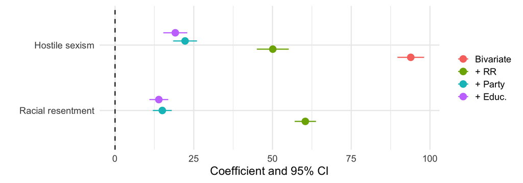

- Same arguments as `modelsummary()`, and it returns a `ggplot`, so `+` works
- `coef_map` is reversed because ggplot draws the first level at the bottom

## By hand

```r
coefs <- map(models, \(m) broom::tidy(m, conf.int = TRUE)) |>
  list_rbind(names_to = "model") |>
  filter(term == "hostile_sexism") |>
  mutate(model = fct_inorder(model))

ggplot(coefs, aes(x = estimate, y = fct_rev(model))) +
  geom_vline(xintercept = 0, linetype = "dashed") +
  geom_pointrange(aes(xmin = conf.low, xmax = conf.high),
                  colour = uw_red, size = 0.8, linewidth = 1.2) +
  expand_limits(x = 0) +
  labs(x = "Coefficient on hostile sexism (95% CI)", y = NULL) +
  theme_minimal(base_size = 18)
```

- `broom::tidy()` turns any model into a data frame of estimates. Then it’s just `ggplot`
- One coefficient across specifications: the plot version of reading across the table

## By hand

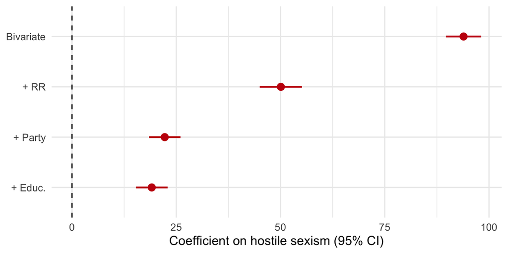

## Reading a coefficient plot

- **Point**: the estimate. **Line**: the 95% CI
- **Crosses the dashed line at 0**: can’t reject $H_0: \beta = 0$ at 5%. Same information as the stars, but you can also see **how big** and **how uncertain**
- Overlapping CIs **do not** imply the coefficients aren’t significantly different from each other. Testing a difference needs the SE of the difference (and its covariance term)
- Coefficients on one plot invite comparisons of **size**. Those comparisons only make sense if a “one-unit change” means something comparable for each variable

## The kitchen-sink model

```r
anes_ks <- anes |> drop_na(age, ideo7, econ)

m_ks <- lm(ft_trump ~ hostile_sexism + racial_resentment + age + pid7 + ideo7 +
             econ + college + woman, data = anes_ks)

labels <- c(hostile_sexism = "Hostile sexism (0-1)", racial_resentment = "Racial resentment (0-1)",
            age = "Age (years)", pid7 = "Party ID (1-7)", ideo7 = "Ideology (1-7)",
            econ = "Economy worse (1-5)", college = "College degree", woman = "Woman")

round(coef(m_ks), 2)
```

```
      (Intercept)    hostile_sexism racial_resentment               age              pid7
           -32.56             13.88             12.83             -0.04              8.97
            ideo7              econ           college             woman
             3.01              4.61             -2.87             -0.58
```

- Every regressor is on its **own** scale. A one-unit change is the whole range of hostile sexism, one year of age, or one step on a 7-point scale

## A nonsensical coefficient plot

```r
modelplot(m_ks, coef_map = rev(labels), vcov = "HC2") +
  geom_vline(xintercept = 0, linetype = "dashed") +
  labs(x = "Coefficient (one-unit change) and 95% CI") +
  theme_minimal(base_size = 16)
```

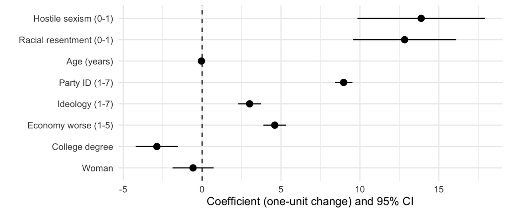

- It looks like hostile sexism matters more than party ID, and age doesn’t matter at all
- But Strong Democrat to Strong Republican is **6** units of `pid7`: $6 \times$ 9 $\approx$ 54 points. And 18 to 80 is **62** years of age

## Rescale, then plot

Gelman (2008): subtract the mean and divide each continuous regressor by **two** SDs. Then a “one-unit change” is low (−1 SD) to high (+1 SD), and is comparable to a 0/1 dummy

```r
rescale_2sd <- function(x) (x - mean(x)) / (2 * sd(x))

anes_std <- anes_ks |>
  mutate(across(c(hostile_sexism, racial_resentment, age, pid7, ideo7, econ), rescale_2sd))

m_std <- lm(ft_trump ~ hostile_sexism + racial_resentment + age + pid7 + ideo7 +
              econ + college + woman, data = anes_std)
```

- Leave the **binary** variables alone: their one-unit change is already the comparison you want
- The fit is identical: same predictions, $R^2$, and $t$-statistics. Only the **units** of the coefficients change
- An alternative when scales have natural endpoints: put everything on 0 to 1, so each coefficient is a min-to-max difference

## Before and after

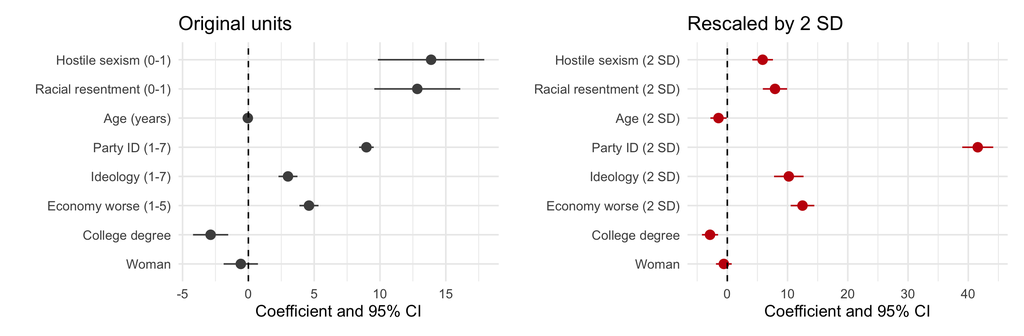

- Now **party ID** dominates (42 points), as you’d expect for a feeling thermometer about a presidential candidate. Hostile sexism is 5.9
- The ranking of “what matters” depends on choices about units. **Make them on purpose and say what they are**

# Marginal effects

## When is a coefficient the answer?

In a linear model with no interactions or transformations, the slope of the prediction with respect to $X_1$ **is** $\beta_1$:

$$\frac{\partial}{\partial x_1}\big(\beta_0 + \beta_1 x_1 + \beta_2 x_2\big) = \beta_1$$

```r
library(marginaleffects)

fit_add <- lm(ft_trump ~ hostile_sexism + racial_resentment, data = anes)
avg_slopes(fit_add)
```

```
              Term Estimate Std. Error    z Pr(>|z|)     S 2.5 % 97.5 %
 hostile_sexism        50.1       2.46 20.4   <0.001 304.2  45.3   54.9
 racial_resentment     60.4       1.70 35.5   <0.001 912.2  57.1   63.8

Type: response
Comparison: dY/dX
```

- Same numbers as column (2) of the table (up to the SEs, which `lm()` computes the classical way). So for this model, `marginaleffects` adds nothing
- It starts to matter once the slope **depends on where you are**: interactions and polynomials

## The vocabulary

- **Predictions**: the model’s fitted $\hat Y$ at some values of $X$
- **Comparisons**: the difference in predictions between two values of $X$ (e.g. hostile sexism 0 vs. 1)
- **Slopes**: the derivative $\partial \hat Y / \partial X$, the “marginal effect”
- Each can be computed **per row** of the data (`slopes()`), **averaged** (`avg_slopes()`), or **plotted** (`plot_slopes()`). Same for `predictions()` and `comparisons()`
- Every function returns standard errors and CIs, using the model’s variance-covariance matrix. No more computing $\text{Var}(\hat\beta_1) + x^2\,\text{Var}(\hat\beta_3) + 2x\,\text{Cov}(\cdot)$ by hand, which is what we did for the band last week
- “Effect” is the package’s word. Without a design that identifies a causal effect, read it as a **slope**

## Interactions: the slope depends on the moderator

```r
fit_col <- lm(ft_trump ~ hostile_sexism * college, data = anes)
round(coef(fit_col), 2)
```

```
           (Intercept)         hostile_sexism                college hostile_sexism:college
                 15.48                  79.04                 -14.52                  20.49
```

```r
avg_slopes(fit_col, variables = "hostile_sexism", by = "college", vcov = "HC2")
```

```
 college Estimate Std. Error    z Pr(>|z|)     S 2.5 % 97.5 %
       0     79.0       3.52 22.5   <0.001 368.9  72.1   85.9
       1     99.5       2.86 34.8   <0.001 878.7  93.9  105.1

Term: hostile_sexism
Type: response
Comparison: dY/dX
```

- `college = 0`: the slope is $\hat\beta_1$. `college = 1`: it’s $\hat\beta_1 + \hat\beta_3$, **with an SE** for the sum
- The coefficient table never shows you the second number directly

## Polynomials: two coefficients, one slope

```r
fit_quad <- lm(ft_trump ~ hostile_sexism + I(hostile_sexism^2), data = anes)
round(coef(fit_quad), 2)
```

```
        (Intercept)      hostile_sexism I(hostile_sexism^2)
               1.63              130.46              -49.05
```

```r
avg_slopes(fit_quad, variables = "hostile_sexism", vcov = "HC2")
```

```
 Estimate Std. Error    z Pr(>|z|)   S 2.5 % 97.5 %
     96.8       2.03 47.6   <0.001 Inf  92.8    101

Term: hostile_sexism
Type: response
Comparison: dY/dX
```

- The slope on hostile sexism is $\hat\beta_1 + 2\hat\beta_2 x$. Neither coefficient alone is “the slope”, and $\hat\beta_1 =$ 130.5 is only the slope at $x = 0$
- `avg_slopes()` averages $\hat\beta_1 + 2\hat\beta_2 x$ over the respondents: 96.8, with an SE

## Polynomials: the slope changes along $X$

```r
plot_slopes(fit_quad, variables = "hostile_sexism", condition = "hostile_sexism", vcov = "HC2") +
  geom_hline(yintercept = 0, linetype = "dashed") +
  labs(x = "Hostile sexism", y = "Slope of hostile sexism") +
  theme_minimal(base_size = 20)
```

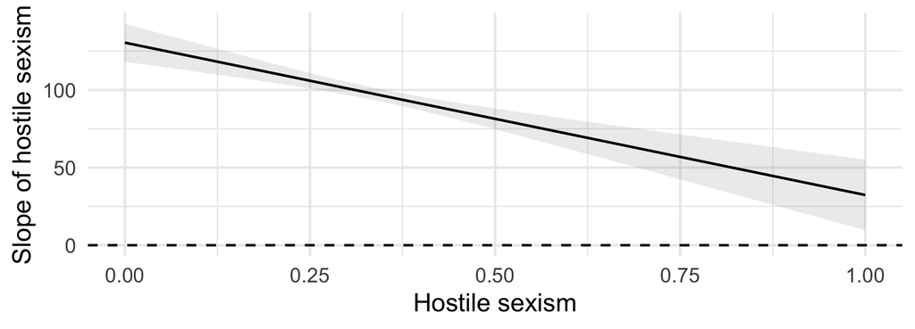

- The slope falls from 130 at the bottom of the scale to 32 at the top: the thermometer runs out of room near 100, as in the lecture’s binned estimates
- Reporting $\hat\beta_1$ as “the effect” would overstate the slope for almost everyone. The **average** slope is one honest summary

## Visualizing interactions: predictions

```r
plot_predictions(fit_col, condition = list("hostile_sexism", college = 0:1), vcov = "HC2") +
  labs(x = "Hostile sexism", y = "Predicted Trump thermometer", colour = "College", fill = "College")
```

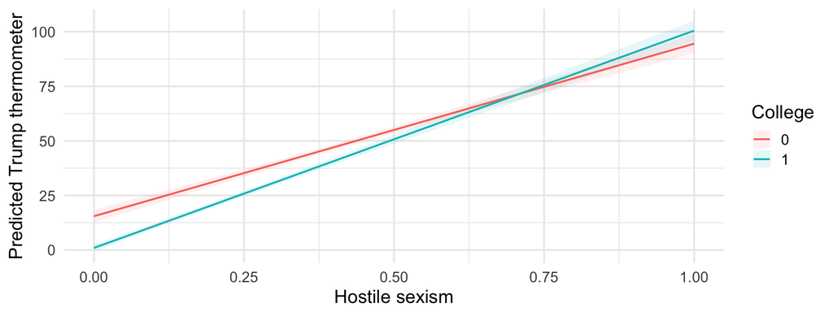

- One line per value of the moderator, with 95% bands. Different slopes = the interaction

## Visualizing interactions: the marginal effects plot

```r
fit_rr <- lm(ft_trump ~ hostile_sexism * racial_resentment, data = anes)

plot_slopes(fit_rr, variables = "hostile_sexism", condition = "racial_resentment", vcov = "HC2") +
  geom_hline(yintercept = 0, linetype = "dashed") +
  geom_rug(data = anes, aes(x = jitter(racial_resentment, amount = 0.01)),
           inherit.aes = FALSE, alpha = 0.05) +
  labs(x = "Racial resentment", y = "Slope of hostile sexism") +
  theme_minimal(base_size = 20)
```

- The lecture’s plot, in one call. The rug shows **where the data are**
- Still a straight line by construction: check it with the binned estimator from lecture before believing it

## Visualizing interactions: the marginal effects plot

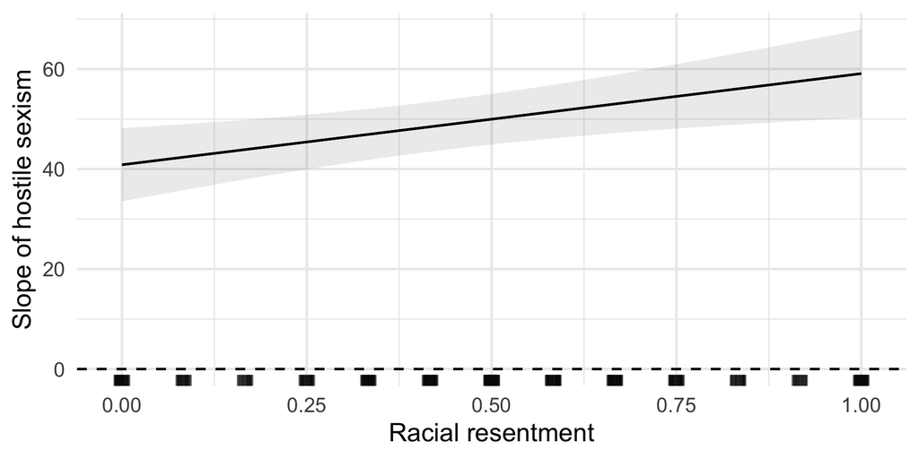

## Taking control of the plot

```r
me <- plot_slopes(fit_rr,
                  variables = "hostile_sexism",
                  condition = "racial_resentment",
                  vcov = "HC2", draw = FALSE)

ggplot(me, aes(x = racial_resentment, y = estimate)) +
  geom_hline(yintercept = 0, linetype = "dashed") +
  geom_ribbon(aes(ymin = conf.low, ymax = conf.high),
              fill = uw_red, alpha = 0.2) +
  geom_line(colour = uw_red, linewidth = 1.2) +
  labs(x = "Racial resentment",
       y = "Slope of hostile sexism\non the Trump thermometer") +
  theme_minimal(base_size = 18)
```

- `draw = FALSE` returns the data behind the plot. Then style it like any other `ggplot`

## Taking control of the plot

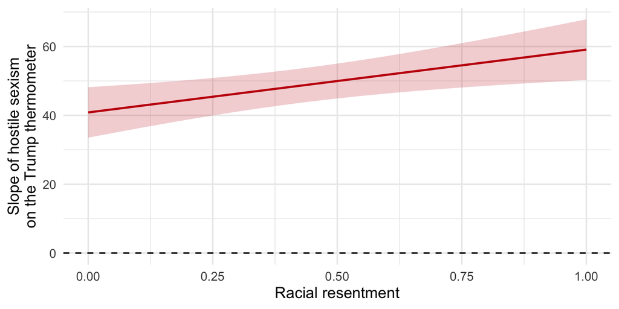

# Getting it out of R

## Tables

```r
modelsummary(models, output = "tab_main.tex")     # LaTeX: \input{} it in your paper
modelsummary(models, output = "tab_main.docx")    # Word
modelsummary(models, output = "tab_main.png")     # an image, for slides
gtsave(tab, "tab_main.png")                       # after gt styling
```

- In a Quarto document, just call `modelsummary()` in a chunk. It picks the right format for HTML or PDF output
- Write tables **from code**, never by copying numbers. When the data change, you re-run and every number updates

## Figures

```r
p <- p_raw + p_std
ggsave("fig_coefplot.pdf", p, width = 6.5, height = 4)            # vector: LaTeX papers
ggsave("fig_coefplot.png", p, width = 6.5, height = 4, dpi = 300)  # raster: Word, slides
```

- Set `width` and `height` to the size the figure will **appear** at (6.5 in. is a page width). Then the font sizes come out right, instead of being shrunk or blown up
- In Quarto: `#| fig-width:`, `#| fig-height:`, and `#| fig-cap:`, with a `fig-` label for cross-references

## What’s wrong with this table?

|  | (1) | (2) | (3) | (4) |
| --- | --- | --- | --- | --- |
| (Intercept) | 6.23060 (<1e-05) | 0.12811 (0.93715) | -20.51879 (<1e-05) | -21.88591 (<1e-05) |
| hostile_sexism | 93.98384 (<1e-05) | 49.72504 (<1e-05) | 15.48347 (<1e-05) | 18.27463 (<1e-05) |
| racial_resentment |  | 62.32253 (<1e-05) | 15.37439 (<1e-05) | 15.53832 (<1e-05) |
| age |  | -0.19207 (<1e-05) | -0.10250 (<1e-05) | -0.10125 (<1e-05) |
| pid7 |  |  | 9.99437 (<1e-05) | 9.98964 (<1e-05) |
| ideo7 |  |  | 3.58833 (<1e-05) | 3.61805 (<1e-05) |
| college |  |  | -4.21958 (<1e-05) | -2.26189 (0.08768) |
| hostile_sexism college |  |  |  | -5.72588 (0.08236) |
| Num.Obs. | 4584 | 4401 | 3821 | 3821 |
| R2 | 0.252 | 0.422 | 0.729 | 0.729 |
| R2 Adj. | 0.252 | 0.422 | 0.728 | 0.728 |
| AIC | 45316.4 | 42371.7 | 33956.7 | 33955.7 |
| BIC | 45335.6 | 42403.7 | 34006.7 | 34011.9 |
| Log.Lik. | -22655.176 | -21180.861 | -16970.355 | -16968.843 |
| F |  |  | 1705.733 | 1463.262 |
| RMSE | 33.90 | 29.78 | 20.54 | 20.53 |